# Time Series Homework 4

Will Burton

October 8, 2016

Explore the time series data to find patterns and create an optimal model

*1. Determine season and perform stl*

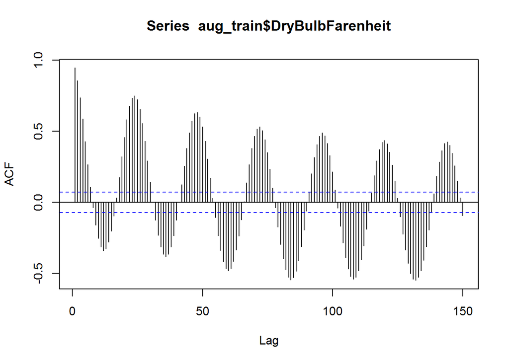

```r
library(forecast)
setwd('C:/Users/Will/Documents/MSA/fall/time_series/homeworks/MSA_HW_4_Time_Series/data')

aug_train <- read.csv('AUGUST_TRAIN_CLEAN.csv')
aug_train <- aug_train[,-4]
sep_valid <- read.csv('SEPTEMBER_VALID_CLEAN.csv')

# Determine the season using acf plot
Acf(aug_train$DryBulbFarenheit, 150)
```

```r
# The Acf shows a season of 24... as expected, this is temperatures in a day
temp <- ts(aug_train$DryBulbFarenheit, frequency = 24)
stl_temp <- data.frame(stl(temp, s.window = 7)$time.series)

head(stl_temp)
```

```
##    seasonal    trend  remainder
## 1 -2.064184 85.85472  1.2094614
## 2 -3.421514 86.11900 -0.6974884
## 3 -4.351844 86.38328 -1.0314388
## 4 -4.416153 86.64756 -1.2314095
## 5 -4.674508 86.91184 -1.2373348
## 6 -5.215847 87.17612 -0.9602755
```

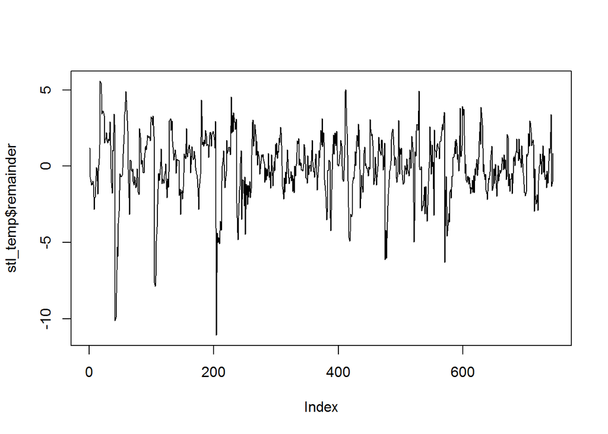

```r
plot(stl_temp$remainder, type = 'l')
```

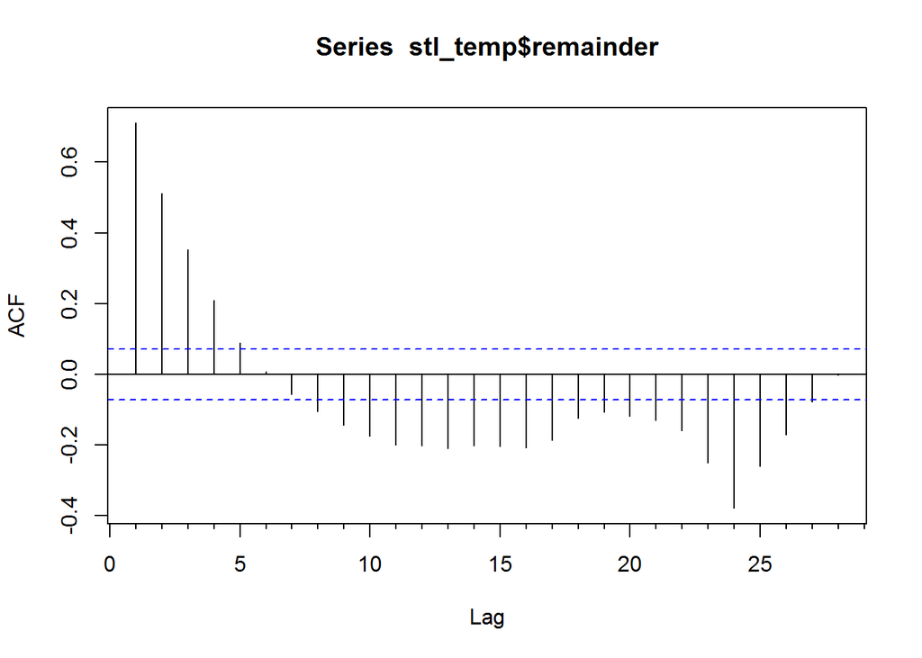

```r
Acf(stl_temp$remainder)
```

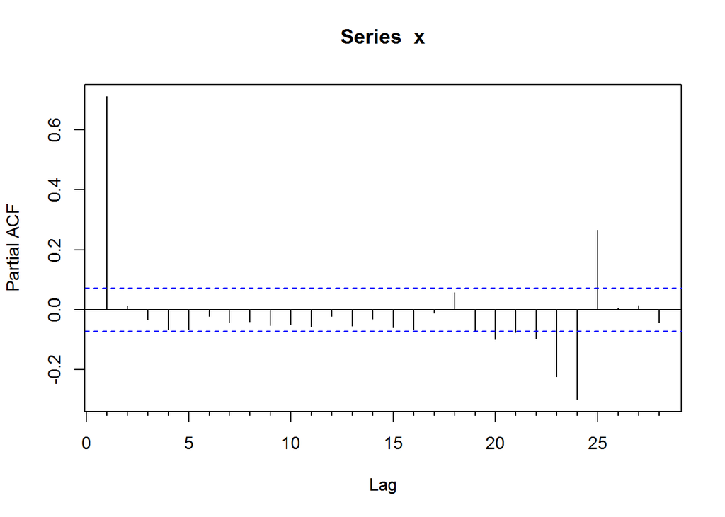

```r
Pacf(stl_temp$remainder)
```

```r
# After removing trend and season there is still autocorrelation in the residuals
```

*2. Create ESM models*

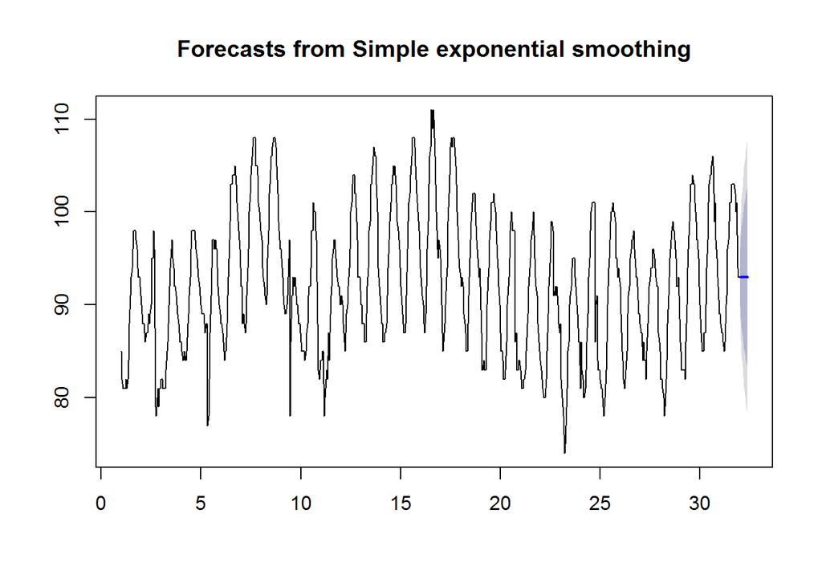

```r
ses_temp <- ses(temp)
plot(ses_temp)
```

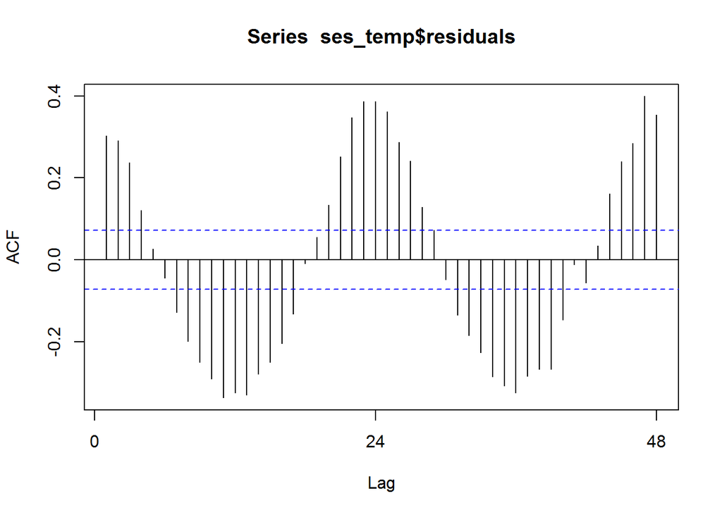

```r
Acf(ses_temp$residuals)
```

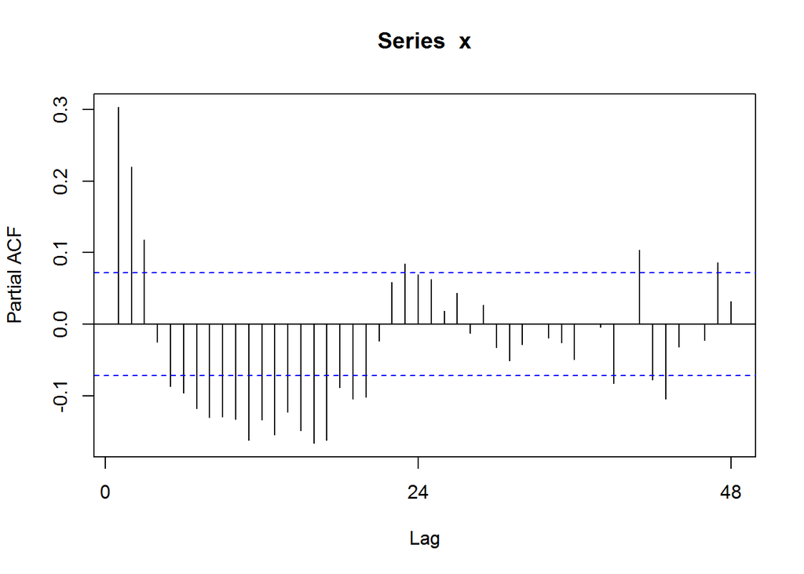

```r
Pacf(ses_temp$residuals)
```

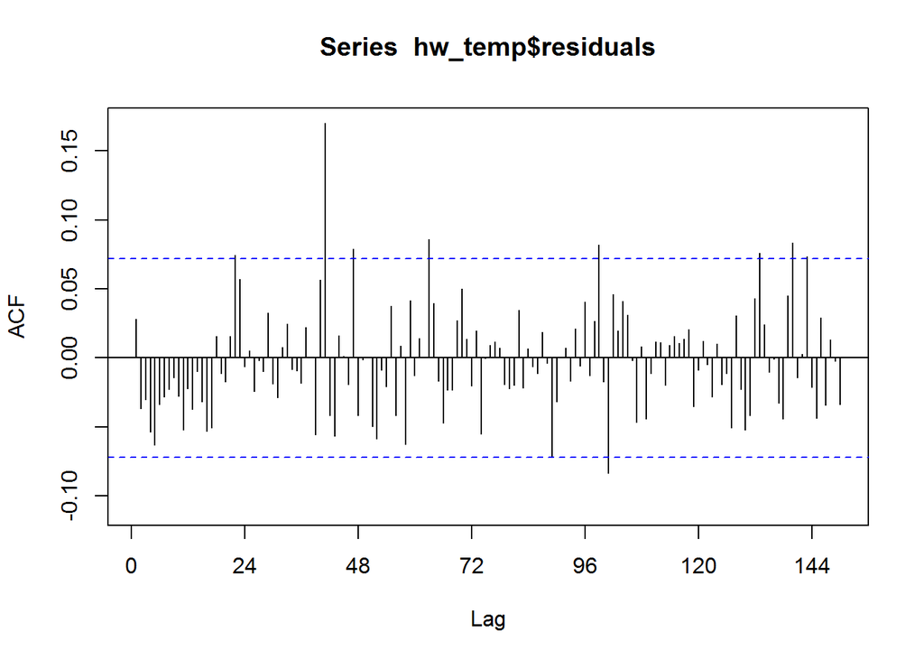

```r
# simple exponential smoothing does not remove season

hw_temp <- hw(temp)
Acf(hw_temp$residuals,150)
```

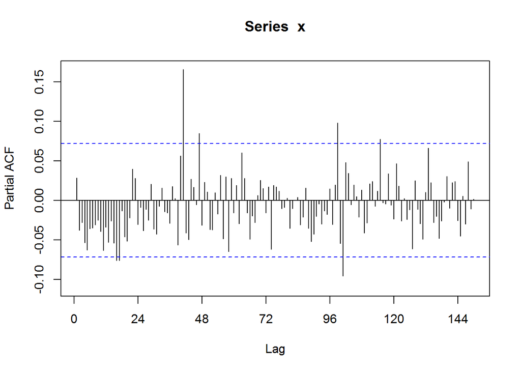

```r
Pacf(hw_temp$residuals,150)
```

```r
# holt winters exponential smoothing does not remove autocorrelation among
# residuals
```

Since there is still pattern in the residuals we need to remove additional patterns using ARIMA models  
Before ARIMA modeling, we need to determine if the data is stationary after removing trend and season. The trend and season will be removed either using deterministic (regression) or stochastic (take a difference) methods. The problem with this data is the season is larger than 12, so the seasonal dickey fuller test will not work. To get around this you can:  
1. Try to adjust the data. ex. if you have season of length 24, take every other point and look at it as if the season was 12.  
2. Try both deterministic (regression) and stochastic (difference) methods and see which is more accurate  
We will try modeling using both methods, deterministic and stochastic and pick the one with the lowest MAPE.

*1. Deterministic approach*

```r
#create hourly binary variables
hours <- rep(1:24, times = length(temp)/24)
hours <- factor(hours)
time <- 1:length(temp)
hours <- model.matrix(~ hours + time)
hours <- hours[,-1]

summary(lm(temp~hours))
```

```
##
## Call:
## lm(formula = temp ~ hours)
##
## Residuals:
##      Min       1Q   Median       3Q      Max
## -20.6259  -3.2315  -0.0361   3.3412  11.3871
##
## Coefficients:
##                Estimate Std. Error t value Pr(>|t|)
## (Intercept)  88.7978019  0.9248487  96.013  < 2e-16 ***
## hourshours2  -1.2576417  1.2370751  -1.017 0.309674
## hourshours3  -2.6443156  1.2370760  -2.138 0.032890 *
## hourshours4  -3.3858283  1.2370774  -2.737 0.006354 **
## hourshours5  -4.2241151  1.2370793  -3.415 0.000675 ***
## hourshours6  -4.7398213  1.2370818  -3.831 0.000139 ***
## hourshours7  -4.0942372  1.2370849  -3.310 0.000981 ***
## hourshours8  -2.2551047  1.2370885  -1.823 0.068732 .
## hourshours9  -0.2546819  1.2370927  -0.206 0.836950
## hourshours10  2.6167087  1.2370975   2.115 0.034756 *
## hourshours11  5.1977767  1.2371028   4.202 2.98e-05 ***
## hourshours12  6.6175543  1.2371087   5.349 1.19e-07 ***
## hourshours13  9.1986223  1.2371151   7.436 2.97e-13 ***
## hourshours14 10.9732387  1.2371221   8.870  < 2e-16 ***
## hourshours15 11.7155970  1.2371297   9.470  < 2e-16 ***
## hourshours16 12.5547295  1.2371378  10.148  < 2e-16 ***
## hourshours17 12.0712814  1.2371464   9.757  < 2e-16 ***
## hourshours18 10.8458977  1.2371557   8.767  < 2e-16 ***
## hourshours19  8.7818044  1.2371654   7.098 3.04e-12 ***
## hourshours20  7.2983563  1.2371758   5.899 5.62e-09 ***
## hourshours21  5.6536178  1.2371867   4.570 5.75e-06 ***
## hourshours22  3.5572665  1.2371982   2.875 0.004156 **
## hourshours23  2.5899474  1.2372102   2.093 0.036665 *
## hourshours24  1.6548863  1.2372228   1.338 0.181456
## hourstime    -0.0004228  0.0008318  -0.508 0.611380
## ---
## Signif. codes:  0 '***' 0.001 '**' 0.01 '*' 0.05 '.' 0.1 ' ' 1
##
## Residual standard error: 4.87 on 719 degrees of freedom
## Multiple R-squared:  0.5868, Adjusted R-squared:  0.573
## F-statistic: 42.54 on 24 and 719 DF,  p-value: < 2.2e-16
```

```r
#time isn't significant so we can say there is no significant trend identified in the data
hours <- hours[,-ncol(hours)]

season_arima <- Arima(temp, xreg = hours, method = 'ML')

summary(season_arima)
```

```
## Series: temp
## ARIMA(0,0,0) with non-zero mean
##
## Coefficients:
##       intercept   hours2   hours3   hours4   hours5   hours6   hours7
##         88.6452  -1.2581  -2.6452  -3.3871  -4.2258  -4.7419  -4.0968
## s.e.     0.8601   1.2163   1.2163   1.2163   1.2163   1.2163   1.2163
##        hours8   hours9  hours10  hours11  hours12  hours13  hours14
##       -2.2581  -0.2581   2.6129   5.1935   6.6129   9.1935  10.9677
## s.e.   1.2163   1.2163   1.2163   1.2163   1.2163   1.2163   1.2163
##       hours15  hours16  hours17  hours18  hours19  hours20  hours21
##       11.7097  12.5484  12.0645  10.8387   8.7742   7.2903   5.6452
## s.e.   1.2163   1.2163   1.2163   1.2163   1.2163   1.2163   1.2163
##       hours22  hours23  hours24
##        3.5484   2.5806   1.6452
## s.e.   1.2163   1.2163   1.2163
##
## sigma^2 estimated as 23.7:  log likelihood=-2220.99
## AIC=4491.97   AICc=4493.79   BIC=4607.28
##
## Training set error measures:
##                       ME     RMSE      MAE       MPE     MAPE     MASE
## Training set 6.55357e-14 4.788702 3.856313 -0.270401 4.200248 1.028731
##                   ACF1
## Training set 0.9216674
```

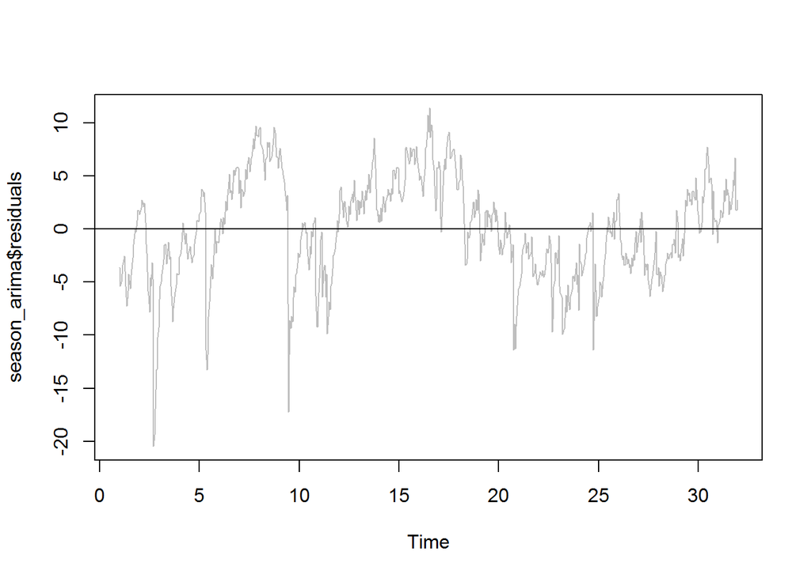

```r
#look at Acf and Pacf on the residuals after adjusting for seasonality
plot(season_arima$residuals, col = 'grey')
abline(h = 0)
```

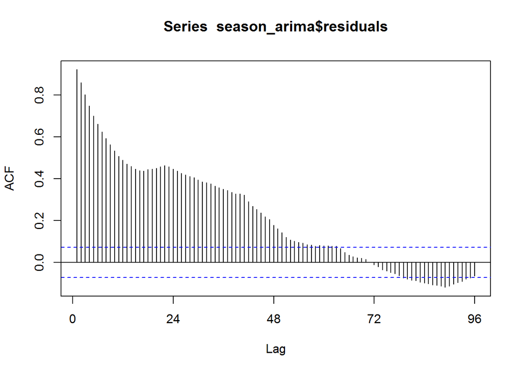

```r
Acf(season_arima$residuals,24*4)
```

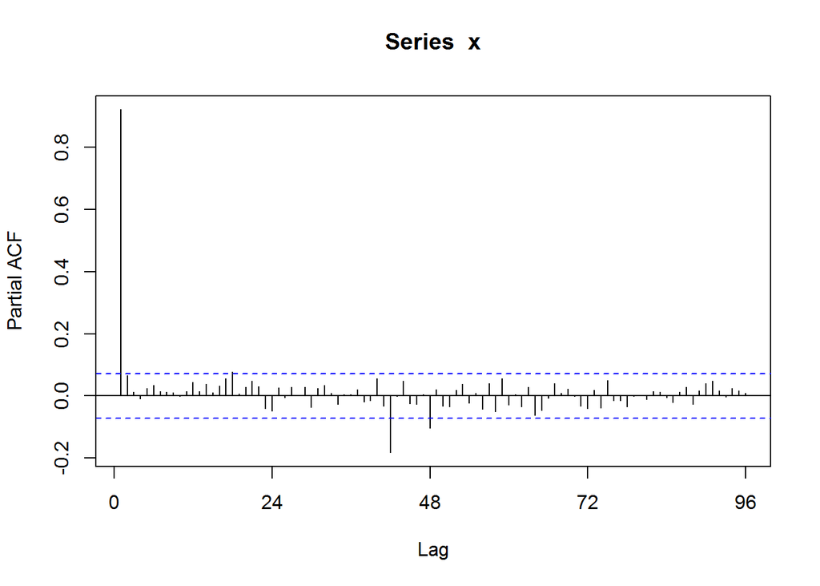

```r
Pacf(season_arima$residuals,24*4)
```

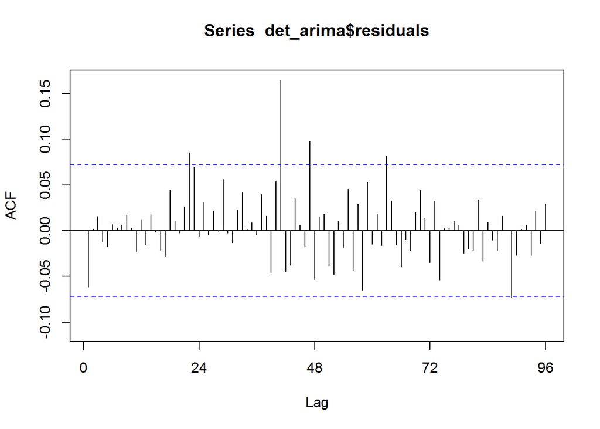

```r
#Now we create an ARIMA model using the stationary data created by removing the season deterministically
det_arima <- Arima(temp,order = c(1,0,0), xreg = hours, method = 'ML')
Acf(det_arima$residuals,24*4)
```

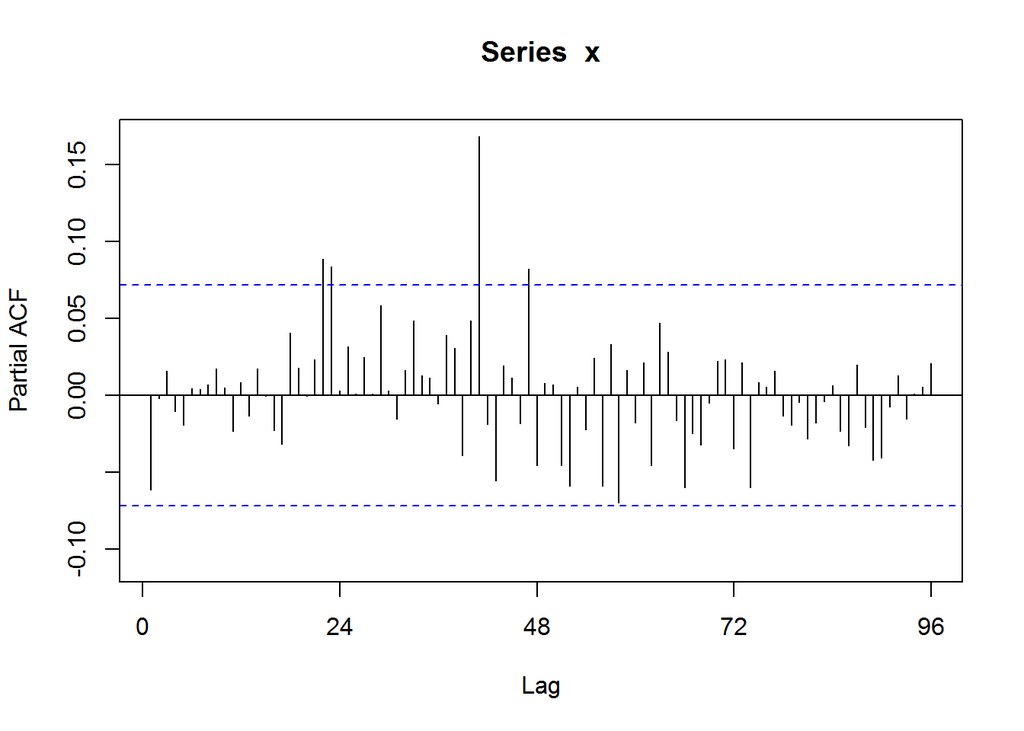

```r
Pacf(det_arima$residuals,24*4)
```

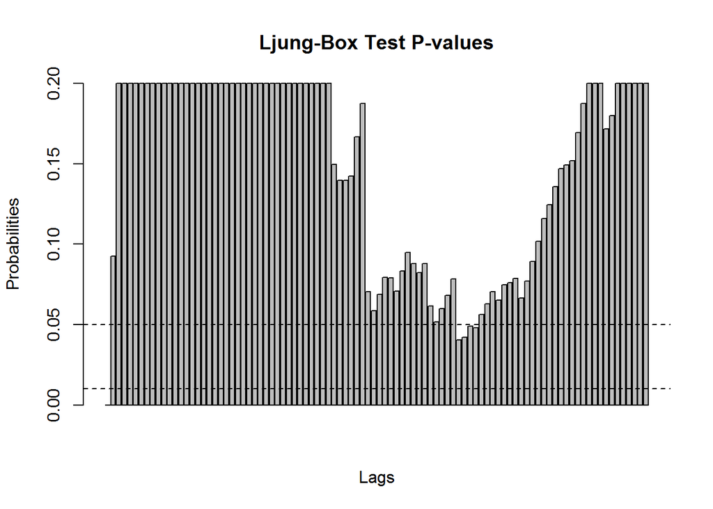

```r
#Look at ljung-box test
White.LB <- rep(NA, 24*4)
for(i in 1:length(White.LB)){
  White.LB[i] <- Box.test(det_arima$residuals, lag = i, type = "Ljung", fitdf = 1)$p.value
}

White.LB <- pmin(White.LB, .2)
barplot(White.LB, main = "Ljung-Box Test P-values", ylab = "Probabilities", xlab = "Lags", ylim = c(0, 0.2))
abline(h = 0.01, lty = "dashed", col = "black")
abline(h = 0.05, lty = "dashed", col = "black")
```

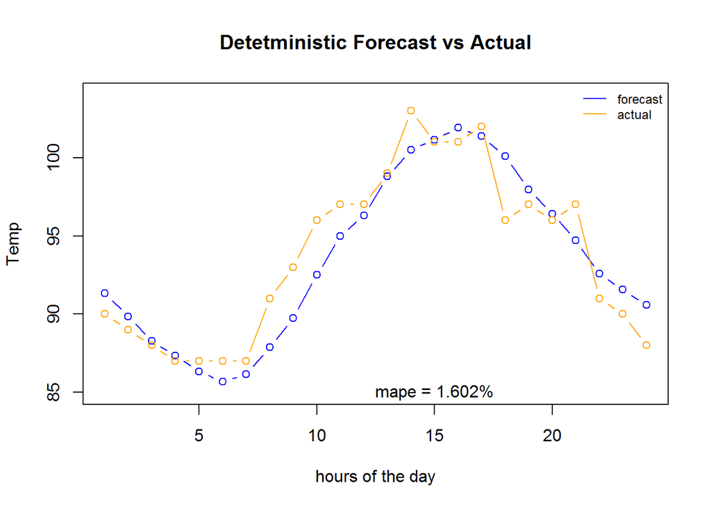

```r
#create mape function
mape <- function(forecast, actual){
  mean(abs(actual-forecast)/actual)
}

#Now check out the mape of the deterministic model
#the model needs the variables for hour in the day, because it was modeled using a variable
# for hour of the day. (To account for seasonality)
hours <- factor(1:24)
hours <- model.matrix(~ hours)
hours <- hours[,-1]

#Calculate the forecast, mape, and plot to compare forecast to actual
det_forecast <- data.frame(forecast(det_arima,xreg = hours, h = 24))$Point.Forecast
mape_det <- mape(det_forecast, sep_valid$DryBulbFarenheit)
plot(y = det_forecast,x = 1:24, type = 'b', col = 'blue', main = "Detetministic Forecast vs Actual",
     xlab = 'hours of the day', ylab ='Temp', ylim = c(85,104) )
lines(y = sep_valid$DryBulbFarenheit, x = 1:24, col = 'orange', type = 'b')
text(x = 15, y = 85, paste0('mape = ', 100*round(mape_det,5),'%'))
legend('topright', c('forecast', 'actual'),
   lty=1, col=c('blue', 'orange'), bty='n', cex=.75)
```

*2. Stochastic Approach*

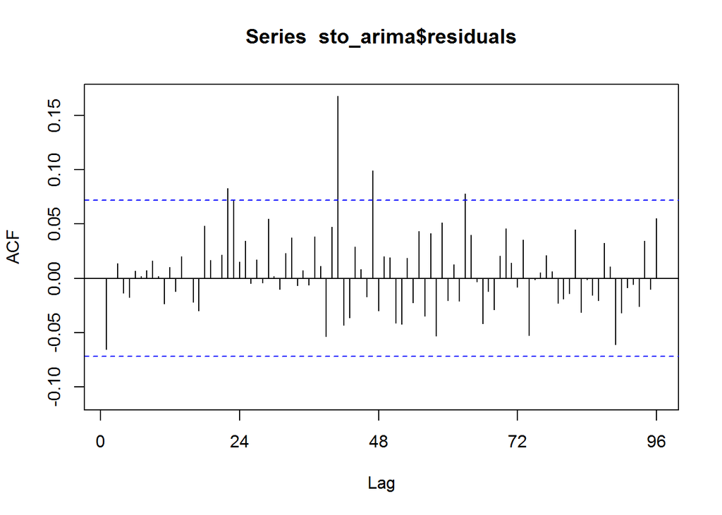

```r
#Take a seasonal difference and add in seasonal MA term and AR-1 term
sto_arima <- Arima(temp,order = c(1,0,0), seasonal = c(0,1,1), method = 'ML')
Acf(sto_arima$residuals, 24*4)
```

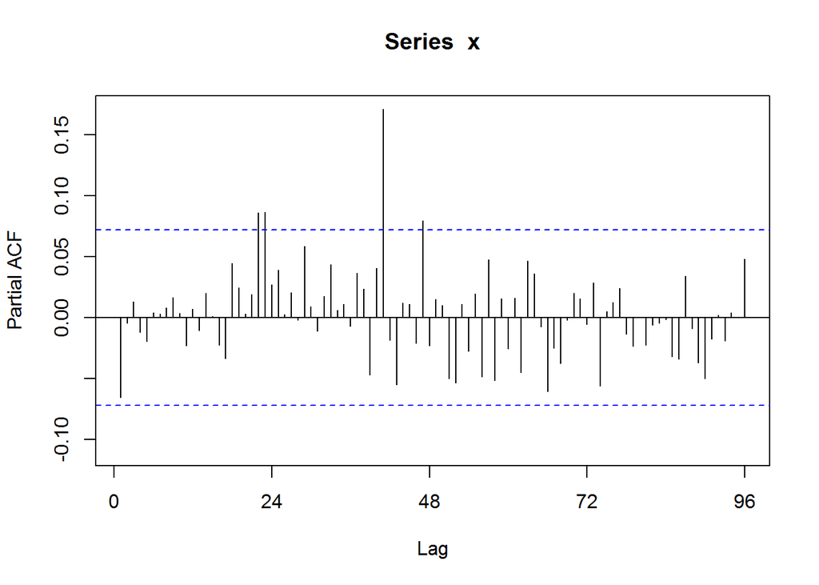

```r
Pacf(sto_arima$residuals, 24*4)
```

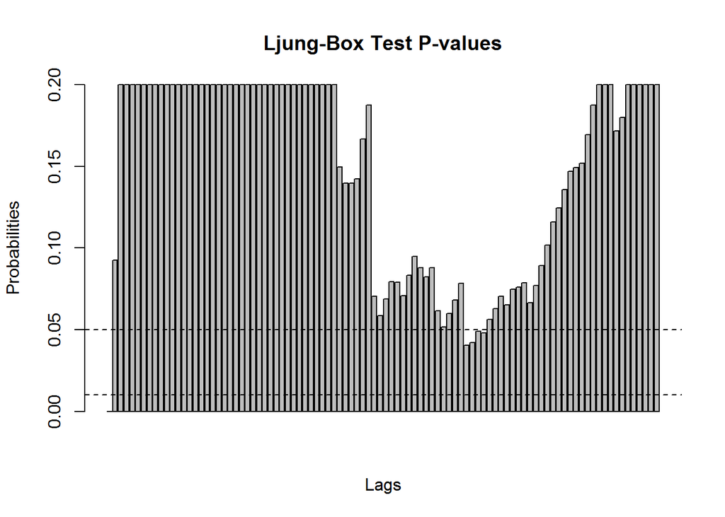

```r
#Look at white noise plots
White.LB <- rep(NA, 24*4)
for(i in 1:length(White.LB)){
  White.LB[i] <- Box.test(det_arima$residuals, lag = i, type = "Ljung", fitdf = 1)$p.value
}

White.LB <- pmin(White.LB, .2)
barplot(White.LB, main = "Ljung-Box Test P-values", ylab = "Probabilities", xlab = "Lags", ylim = c(0, 0.2))
abline(h = 0.01, lty = "dashed", col = "black")
abline(h = 0.05, lty = "dashed", col = "black")
```

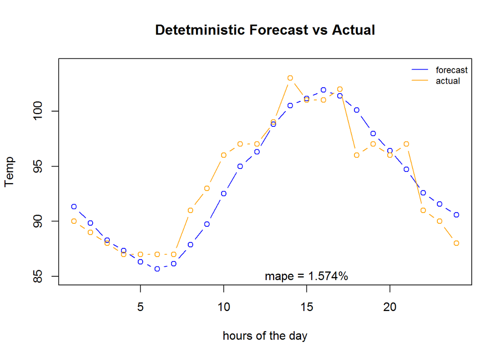

```r
#Calculate mape and plot actual vs. Forecast
sto_forecast <- data.frame(forecast(sto_arima, h = 24))$Point.Forecast
mape_sto <- mape(sto_forecast, sep_valid$DryBulbFarenheit)
plot(y = det_forecast,x = 1:24, type = 'b', col = 'blue', main = "Detetministic Forecast vs Actual",
     xlab = 'hours of the day', ylab ='Temp', ylim = c(85,104) )
lines(y = sep_valid$DryBulbFarenheit, x = 1:24, col = 'orange', type = 'b')
text(x = 15, y = 85, paste0('mape = ', 100*round(mape_sto,5),'%'))
legend('topright', c('forecast', 'actual'),
   lty=1, col=c('blue', 'orange'), bty='n', cex=.75)
```

After analyzing both plots, I would choose an stochastic ARMA(1,0,0)(0,1,1)_24 model. THis model had the lower mape when compared to the deterministic approach

#### Questions for Dr. Labarr:

1. Is there a stationarity chart ? A visual way to inspect for stationrity? Or is the only available test the ADF test (which is really just testing whether a random walk is present or not)
2. Can you describe what it means to be deterministic vs. stochastic?

In deterministic models, the output of the model is fully determined by the parameter values and the initial conditions. LaBarr:

Stochastic models possess some inherent randomness. The same set of parameter values and initial conditions will lead to an ensemble of different outputs. LaBarr:

How to do the seasonal ADF test in R :  
nsdiffs(temp) - it tells you how many seasonal differences to take (0 or 1, I do need to take a difference or I do not) ndiffs(diff(temp, lag = 12)), how many regular differences to take beyond the seasonal difference)